# Bayesian Designs for Phase II Clinical Trials

August 9, 2016

## Introduction for Bayesian designs

## Overview of the current clinical trials

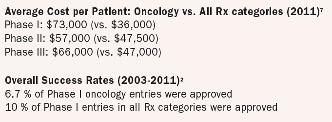

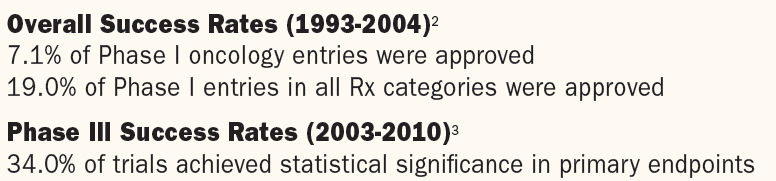

## Why Using Bayesian Methods in Phase II trials?

Phase II clinical trials goals:

1. obtain a precise estimate of the response rate of the new drug
2. make GO/NO GO decisions for further testing in a phase III trial.

Advantages of **B**ayesian over **F**requentist:

1. Bayesian methods are natrual and easy to interpret.
2. Bayesian designs allow us to sequentially monitor the trials.
3. There is a bigger opportunity to stop trials earlier. Save money!

*Note*: In the early phase II development of the oncology drugs, most trials are **open label**, **single-arm** studies.

## Traditional Approaches in Phase II Oncology Study

1. **Gehan's** Two-stage Design (1961) *Cited by 664*
   - "14+11". Simplicity.
2. **Fleming's** Two-stage Design (1982) *Cited by 864*
   - Group Sequential Design, stop for both futility and efficacy
3. **Simon's** Two-stage Design (1989) *Cited by* **2609**
   - Early stop for futility only

Simon's design is the most popular design method in phase II oncology study.

## Frequentist: Two-stage Design

- Richard Simon (1989) proposed two criteria (minimax and optimal) for selecting sample sizes and critical values for these two-stage designs.  
  \[H_0: p \le p_0 \ versus \ H_1: p \ge p_1 = p_0 + \delta.\]
- Jung SH et al.(2004) proposed admissible designs aim to minimize *linear combination of the expected and maximum sample sizes*, which is called expected risk or Bayes risk.

\[X_1 \sim Bin(n_1,p) ,\ X_2 \sim Bin(n_2,p) \ and \ n=n_1+n_2.\]

- \(PET(p)=Pr(X_1 \le r_1)=\sum\limits_{x_1=0}^{r_1} {n_1\choose x_1} p^x (1-p)^{n_1-x_1}\)
- \(E(N|p)=PET(p) n_1+(1-PET(p))n\)
- Power function: \(\beta(p) = Pr(X_1 > r_1 \cap X_1+X_2 > r)\)

## Search Criteria

Under the constraints on **type I error** (\(\beta(p_0)\le \alpha\)) and **power** (\(\beta(p_1) \ge power\)), the design parameters \((n_1, r_1, n, r)\) can be searched to meet one of the following criteria:

- Optimal: minimize the expected sample size \(E(N|p_0)\)
- Minimax: minimize the maxumum sample size \(n_1+n_2\).
- Admissible: minimize the Bayes risk via convex hull (contains Optimal and Minimax designs).

## Toolkits for Simon's Design (I):

- R function `ph2simon` in package `clinfun`.

```r
library(clinfun)
ph2simon(pu=0.15, pa=0.3, ep1 = 0.05, ep2=0.1, nmax = 100)
```

```
##
##  Simon 2-stage Phase II design
##
## Unacceptable response rate:  0.15
## Desirable response rate:  0.3
## Error rates: alpha =  0.05 ; beta =  0.1
##
##         r1 n1  r  n EN(p0) PET(p0)
## Optimal  5 30 17 82  45.05  0.7106
## Minimax  6 42 14 64  51.80  0.5545
```

## Toolkits for Simon's Design (II):

However, the function does not provide the information of type I error, power. We also want to find the admissible designs.

- We build a function `binom.design` including the class of admissible designs, which provides the **operating characteristic** information and **visualization options** for the design selections.

```r
source("simon_admissible.R")
binom.design(output="admissible", p0=0.15, p1=0.30,
      signif.level = 0.05, power.level = 0.9, plot.out = T)
```

## Example output

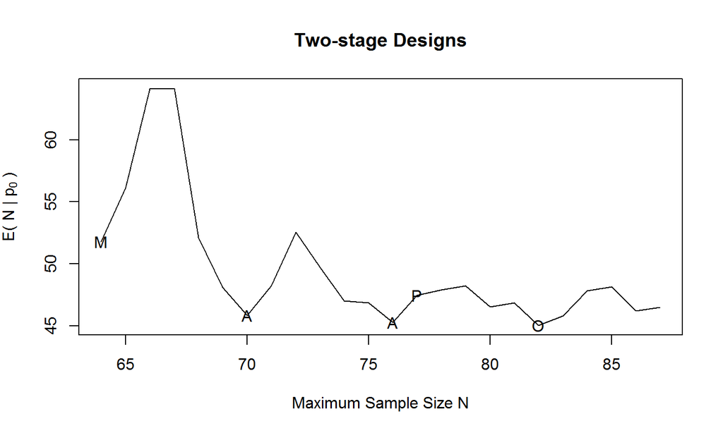

```
##              r1 n1  r  n EN.p0. PET.p0.   error  power
## Optimal       5 30 17 82  45.05  0.7106 0.04609 0.9007
## Admissible    5 31 16 76  45.28  0.6827 0.04695 0.9037
## Admissible.1  6 36 15 70  45.86  0.7099 0.04655 0.9001
## Minimax       6 42 14 64  51.80  0.5545 0.04846 0.9003
```

## Bayesian: Sequential Monitor

- Prior: \[p \sim Beta(a, b).\]
- Observed Data (likelihood): \[x \sim Binomial(n,p). \]
- Posterior: \[p|x \sim Beta(a + x, b + n - x).\]
- Predictive: \[Y|x \sim Beta-Binomial(N_{max}-n, a + x, b + n - x)\]

## Prior and posterior distributions (Web tool)

We build a website using Shiny, it help look into the relationship among prior, observed data and posteror distribution. https://allen.shinyapps.io/Beta_Bayes_Prior/

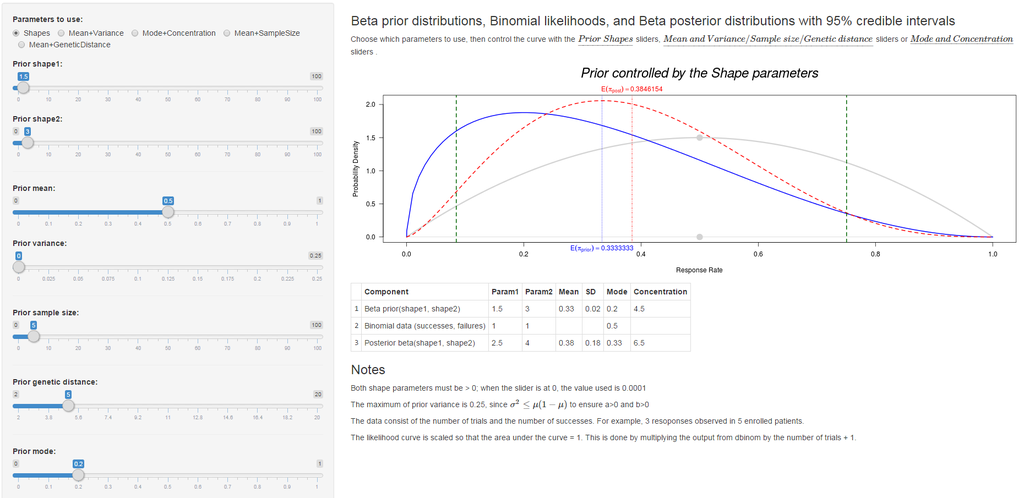

Display of the web application.

## Simulation Example

Consider *objective response rate* (ORR) as the primary endpoint with the following hypotheses: \[H_0: ORR \le 15\% \quad versus \quad H_1: ORR > 15\%.\]

```
## Prior: Beta(0.5,0.5)
```

[video not shown]

## Simulation Example (II)

We can observe after 10 patients enrolled, the difference between posterior and true response rate reduced to a stable level below 3%.

```
## Prior: Beta(0.5,0.5)
```

[video not shown]

## Prior selection: Non-informative priors

1. **Jeffery prior**:
   - a=0.5
   - b=0.5
- The prior sample size is 1, mean = 0.5, variance = 0.125 (Data dominate)
- **Remark**: Compared Unif(0,1) prior, whose variance is 1/12=0.0833, Jeffery prior is more flat and less informative.
1. **Optimist's prior**:
   - \(a=ORR_{prior}+1\)
   - \(b=(1-ORR_{prior})+1\)
- The prior sample size = 3, centered around \(ORR_{prior}\).
- Such a prior distribution is sufficiently vague to allow for the possibility that \(ORR\) may take any value in the range \(0<ORR<1\).

## Prior selection: Informative priors:

1. **Based on prior ORR and Sample size ("ORR+N")**:
   - \(a=ORR_{prior}+1+N_{prior}ORR_{prior}\)
   - \(b=(1-ORR_{prior})+1+N_{prior}(1-ORR_{prior})\)
- The prior sample size = \(3+N_{prior}\).
- It is similar to use mean=\(ORR_{prior}\) and variance= \(\frac{ORR_{prior}(1-ORR_{prior})}{N_{prior}}\), where the sample size = \(N_{prior}-1\)
1. **Based on prior ORR and Width of confidence interval ("ORR+W")**:
   - \(ORR_{prior}=\dfrac{a}{a+b}\)
   - \(W_{95}=F^{-1}(0.975; a,b)-F^{-1}(0.025; a,b)\)
- Solve the non-linear equations for \(a\) and \(b\)

## GO / NO GO Decision: Posterior Probability

\(PostP=Pr(p>p_0|x)\)

### Algorithm 1

- **Step 1:** Specify the upper and lower probability cutoffs \(\theta_U\) and \(\theta_L\). Typically, \(\theta_U \in [0.9,1]\) for efficacy and \(\theta_L \in [0,0.05]\) for futility, true null response rate \(p_0\).
- **Step 2:** Let \[S_U =\min \{x \in \mathbb{N}: PostP > \theta_U \}\] and \[ S_L =\max \{x \in \mathbb{N}: PostP < \theta_L \}\]
- **Step 3:** Make decisions after observing another \(x\) responses out of \(n\) patients:
  - If \(x \ge S_U\), then stop the trial for efficacy;
  - if \(x \le S_L\), then stop the trial for futility;
  - otherwise, continue the trial until \(N_{max}\) reached.

## GO / NO GO Decision: Predictive Probability

\(PredP = Pr_{Y|x} \{Pr(p>p_0|x, Y) \ge \theta_T \}\)

### Algorithm 2

- **Step 1:** Specified the upper and lower probability cutoffs \(\theta_U\) and \(\theta_L\), typically, \(\theta_U \in [0.9,1]\) for efficacy and \(\theta_L \in [0,0.05]\) for futility. Specified cutoff \(\theta_T\) for the future \(y\) patients, typically, \(\theta_T \in [0.8,1]\). Set true null response rate \(p_0\) a pre-specified value.
- **Step 2:** Given \(x\) obwervations, let \[S_U =\min \{x+y \in \mathbb{N}: PredP > \theta_U \}\] and \[ S_L =\max \{x+y \in \mathbb{N}: PredP < \theta_L \}\] be the upper and lower decision boudries based on the number of observed responses.

## GO / NO GO Decision: Predictive Probability

\(\begin{aligned} PredP & = Pr_{Y|x} \{Pr(p>p_0|x, Y) \ge \theta_T \} \\ & = \sum\limits_{y=0}^{N_{max} -n} I[Pr(p>p_0|x, Y=y) \ge \theta_T] \times Pr(Y=y|x). \label{predp} \end{aligned}\)

### Algorithm 2 (Cont.)

- **Step 3:** Make decisions after observing another \(x\) responses out of \(n\) patients:
  - If \(x \ge S_U\), then stop the trial for efficacy ;
  - if \(x \le S_L\), then stop the trial for futility;
  - otherwise, continue the trial until \(N_{max}\) reached.

**Remark**: If there were no indicator function in the formula, the PredP simply reduces to the PostP after averaging out the unobserved Y.

\[\sum\limits_{y=0}^{N_{max} -n} Pr(p>p_0|x, Y=y) \times Pr(Y=y|x) = Pr(p>p_0|x)\]

## Practical Examples

## Design for R2810 Phase II Clinical Trials

- **Data reference**: R2810 - RECIST (verson 1.1) Overall Response Investigator (PD, SD, CR or PR)
- **Aim of study**: According to current data and prior competitors' information, make interim analysis, determine suitable stopping rule.
- **Study design**:
  - **Two-stage Design**: Admissible designs
  - **Sequential monitor**:
    1. Posterior probability
    2. Predictive probability.
- **Outcome measure**: **ORR** is determined by the proportion of patients with best overall response of CR or PR among patients in SAF.
- **Prior information**:
  1. *KEYTRUDA* (\(ORR=0.236, N=173, W_{95}=0.186\))
  2. *OPDIVO* (\(ORR=0.317, N=120, W_{95}=0.173\))

## Data Summary

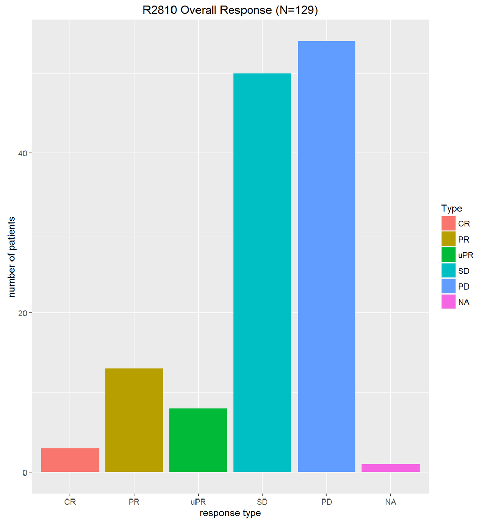

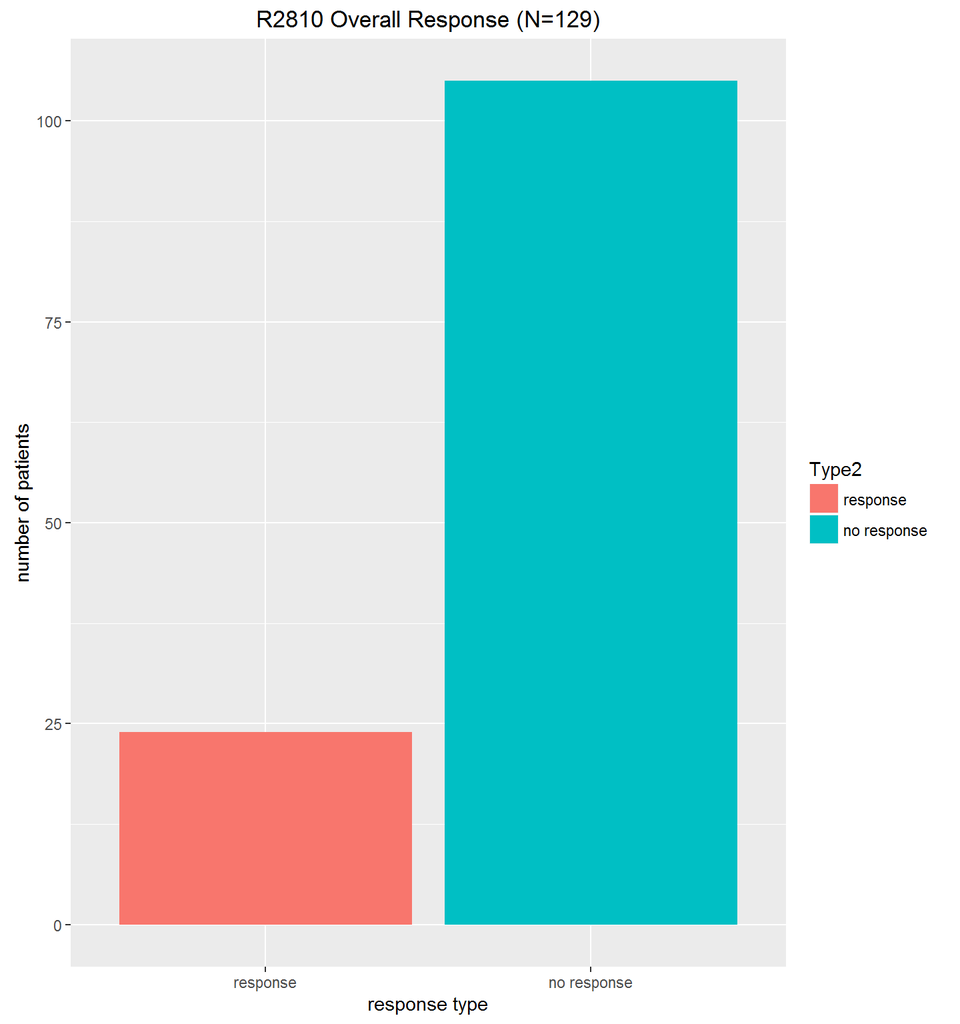

[output not shown]

## Exact Binomial Test

Based on the mean \(\mu\) and the variance \(\sigma^2\), we can derive the prior parameter of \(Beta(a,b)\) distribution with \[a=\mu\left\{\frac{\mu(1-\mu)}{\sigma^2}-1\right\}\] and \[b=(1-\mu)\left\{\frac{\mu(1-\mu)}{\sigma^2}-1\right\}.\]

Because of a relationship between the cumulative binomial distribution and the beta distribution, the Clopper-Pearson interval is sometimes presented in an alternate format that uses quantiles from the beta distribution.

\[ B\left(\frac{\alpha}{2}; x, n - x + 1\right) < \theta < B\left(1 - \frac{\alpha}{2}; x + 1, n - x\right)\]

## Processing Data By Time-to-event

```r
order.data <- response[order(response$TRTSDTM),c("TRTSDTM","AVALC")]
print(cbind(head(order.data,5), tail(order.data,5)),row.names=FALSE)
```

```
##              TRTSDTM AVALC             TRTSDTM AVALC
##  2015-02-04 09:50:00    SD 2016-04-13 11:07:00    SD
##  2015-02-06 09:08:00    PD 2016-04-18 11:05:00    PD
##  2015-02-09 11:15:00    SD 2016-04-18 12:20:00    SD
##  2015-03-16 09:30:00    PD 2016-04-19 08:40:00    PD
##  2015-03-18 09:55:00    PD 2016-04-19 10:42:00    PD
```

```r
rorder <- r01[order(response$TRTSDTM)]
rorder
```

```
##   [1] 0 0 0 0 0 0 0 1 1 0 0 0 0 0 0 0 0 0 1 0 0 0 0 0 0 0 0 1 1 0 0 1 0 1 0
##  [36] 0 0 1 1 0 0 1 0 0 1 1 0 0 0 1 0 0 0 0 0 0 1 0 0 0 0 0 0 0 0 0 0 0 0 0
##  [71] 0 0 1 0 0 0 0 0 0 0 0 0 0 0 0 1 0 0 0 0 1 0 1 0 0 0 0 0 0 0 0 0 0 0 0
## [106] 0 1 0 0 1 1 0 0 1 0 0 0 1 0 0 1 0 0 0 0 0 0 0 0
```

```r
rtotal <- cumsum(r01[order(response$TRTSDTM)])
rtotal
```

```
##   [1]  0  0  0  0  0  0  0  1  2  2  2  2  2  2  2  2  2  2  3  3  3  3  3
##  [24]  3  3  3  3  4  5  5  5  6  6  7  7  7  7  8  9  9  9 10 10 10 11 12
##  [47] 12 12 12 13 13 13 13 13 13 13 14 14 14 14 14 14 14 14 14 14 14 14 14
##  [70] 14 14 14 15 15 15 15 15 15 15 15 15 15 15 15 15 16 16 16 16 16 17 17
##  [93] 18 18 18 18 18 18 18 18 18 18 18 18 18 18 19 19 19 20 21 21 21 22 22
## [116] 22 22 23 23 23 24 24 24 24 24 24 24 24 24
```

## Two-stage Design Analysis

We can use the following program to run the two-stage designs (Optimal, Minimax and Admissible)

```r
binom.design(output="admissible", p0=0.1, p1=0.3, signif.level = 0.05, power.level = 0.9)
```

```
##            r1 n1 r  n EN.p0. PET.p0.  error power
## Optimal     2 18 6 35   22.5   0.734 0.0474 0.902
## Admissible  2 19 6 34   23.4   0.705 0.0438 0.901
## Minimax     2 22 6 33   26.2   0.620 0.0409 0.902
```

## Results for two-stage designs

Except the **admissible** and **minimax** design under **Scenario 1 (\(p_0=0.1\), \(p_1=0.3\))**, other designs will be early terminated for futility for our data.

**We have not used any prior information, although we have!**

[figure not shown]

## Seqential Monitor: `PostP Design`

The Bayesian designs provide a seqence of stopping boundary for response with corresponding sample size. Theoretically we can sequentially monitor the trial based on these rules.

Programming Examples: **Jeffery prior** \(a=b=0.5\)

```r
library(dplyr)
library(ph2bye)
PostP.design(type = "futility", nmax = 129, a=0.5, b=0.5, p0=0.4, theta = 0.05) %>% filter(bound %in% c(4,5,13,14,15)) # filter the design based on Simon's minimum sample size for first stage
```

```
##    n bound
## 1 19     4
## 2 22     5
## 3 46    13
## 4 49    14
## 5 52    15
```

```r
simon.power(r1 = 4, n1=19, r=15, n=52, p = 0.2)
```

```
## [1] 0.0366
```

```r
PostP.design(type = "efficacy", nmax = 129, a=0.5, b=0.5, p0=0.2, theta = 0.9)%>% filter(bound %in% c(4,5,13,14,15))
```

[output not shown]

```r
simon.power(r1 = 4, n1=9, r=15, n=53, p = 0.4)
```

```
## [1] 0.264
```

```r
ani.options(convert='C:\\Users\\yalin.zhu\\Documents\\ImageMagick-7.0.1-10-portable-Q16-x64\\convert.exe')

BB.aniplot(a = 0.5, b = 0.5, r = r01, N = 1, time.interval = 0.01, output = F)

bayes.design(a = 0.5, b = 0.5, r = rorder, stop.rule = "futility", p0 = 0.4, time.interval = 0.1)
bayes.design(a = 0.5, b = 0.5, r = rorder, stop.rule = "efficacy", p0 = 0.2, time.interval = 0.1)
```

```r
source("prior_fun.R")
```

## Optimist's prior: KEYTRUDA : \(a=1.24, b=1.76\)

```r
KT.prior <- optprior(KT.mean); KT.prior # KEYTRUDA optimist's prior
```

```
##    a    b
## 1.24 1.76
```

```r
PostP.design(type = "futility", nmax = 129, a=1.24, b=1.76, p0=0.4, theta = 0.05) %>% filter(bound %in% c(4,5,13,14,15)) # filter the design based on Simon's minimum sample size for first stage
```

```
##    n bound
## 1 19     4
## 2 23     5
## 3 47    13
## 4 50    14
## 5 52    15
```

```r
PostP.design(type = "efficacy", nmax = 129, a=1.24, b=1.76, p0=0.2, theta = 0.9)%>% filter(bound %in% c(4,5,13,14,15))
```

```
##    n bound
## 1  9     4
## 2 12     5
## 3 45    13
## 4 49    14
## 5 53    15
```

```r
bayes.design(a = 1.24, b = 1.76, r = rorder, stop.rule = "futility", p0 = 0.4, time.interval = 0.1)
bayes.design(a = 1.24, b = 1.76, r = rorder, stop.rule = "efficacy", p0 = 0.2, time.interval = 0.1)
```

## Optimist's prior: OPDIVO : \(a=1.32, b=1.68\)

```r
OD.prior <- optprior(OD.mean); OD.prior # OPDIVO optimist's prior
```

```
##    a    b
## 1.32 1.68
```

```r
PostP.design(type = "futility", nmax = 129, a=1.32, b=1.68, p0=0.4, theta = 0.05) %>% filter(bound %in% c(4,5,13,14,15)) # filter the design based on Simon's minimum sample size for first stage
```

```
##    n bound
## 1 20     4
## 2 23     5
## 3 47    13
## 4 50    14
## 5 53    15
```

```r
PostP.design(type = "efficacy", nmax = 129, a=1.32, b=1.68, p0=0.2, theta = 0.9)%>% filter(bound %in% c(4,5,13,14,15))
```

```
##    n bound
## 1  9     4
## 2 13     5
## 3 45    13
## 4 49    14
## 5 53    15
```

```r
bayes.design(a=1.32, b=1.68, r = rorder, stop.rule = "futility", p0 = 0.4, time.interval = 0.1)
bayes.design(a=1.32, b=1.68, r = rorder, stop.rule = "efficacy", p0 = 0.2, time.interval = 0.1)
```

## ORR+N prior: KEYTRUDA : \(a=42.1, b=133.9\)

```r
KT.prior <- ORRNprior(KT.mean, KT.n); KT.prior # KEYTRUDA optimist's prior
```

```
##     a     b
##  42.1 133.9
```

```r
PostP.design(type = "futility", nmax = 129, a=42.1, b=133.9, p0=0.4, theta = 0.05) %>% filter(bound %in% c(4,5,13,14,15)) # filter the design based on Simon's minimum sample size for first stage
```

```
##    n bound
## 1  4     4
## 2  5     5
## 3 13    13
## 4 14    14
## 5 15    15
```

```r
PostP.design(type = "efficacy", nmax = 129, a=42.1, b=133.9, p0=0.2, theta = 0.9)%>% filter(bound %in% c(4,5,13,14,15))
```

```
##    n bound
## 1 13     4
## 2 18     5
## 3 54    13
## 4 59    14
## 5 64    15
```

```r
bayes.design(a=42.1, b=133.9, r = rorder, stop.rule = "futility", p0 = 0.4, time.interval = 0.1)
bayes.design(a=42.1, b=133.9, r = rorder, stop.rule = "efficacy", p0 = 0.2, time.interval = 0.1)
```

```r
OD.prior <- ORRNprior(OD.mean, OD.n); OD.prior # OPDIVO optimist's prior
```

```
##    a    b
## 39.4 83.6
```

```r
PostP.design(type = "futility", nmax = 129, a=39.4, b=83.6, p0=0.4, theta = 0.05) %>% filter(bound %in% c(4,5,13,14,15)) # filter the design based on Simon's minimum sample size for first stage
```

```
##    n bound
## 1  9     4
## 2 11     5
## 3 33    13
## 4 36    14
## 5 39    15
```

```r
PostP.design(type = "efficacy", nmax = 129, a=39.4, b=83.6, p0=0.2, theta = 0.9)%>% filter(bound %in% c(4,5,13,14,15))
```

```
##     n bound
## 1  54     4
## 2  58     5
## 3  95    13
## 4 100    14
## 5 104    15
```

```r
bayes.design(a=39.4, b=83.6, r = rorder, stop.rule = "futility", p0 = 0.4, time.interval = 0.1)
bayes.design(a=39.4, b=83.6, r = rorder, stop.rule = "efficacy", p0 = 0.2, time.interval = 0.1)
```

## ORR+W prior: KEYTRUDA: \(a=18.5, b=59.9\)

```r
KT.prior <- ORRWprior(KT.mean, KT.W);  # KEYTRUDA optimist's prior
```

```r
PostP.design(type = "futility", nmax = 129, a=18.5, b=59.9, p0=0.4, theta = 0.05) %>% filter(bound %in% c(4,5,13,14,15)) # filter the design based on Simon's minimum sample size for first stage
```

```
##    n bound
## 1  4     4
## 2  5     5
## 3 20    13
## 4 23    14
## 5 26    15
```

```r
PostP.design(type = "efficacy", nmax = 129, a=18.5, b=59.9, p0=0.2, theta = 0.9)%>% filter(bound %in% c(4,5,13,14,15))
```

```
##    n bound
## 1  5     4
## 2  9     5
## 3 45    13
## 4 49    14
## 5 54    15
```

```r
bayes.design(a=18.5, b=59.9, r = rorder, stop.rule = "futility", p0 = 0.4, time.interval = 0.1)

bayes.design(a=18.5, b=59.9, r = rorder, stop.rule = "futility", p0 = 0.25, time.interval = 0.1)
# [1] "Stop the trial for futility after the inclusion of 83 patients."
bayes.design(a=18.5, b=59.9, r = rorder, stop.rule = "efficacy", p0 = 0.2, time.interval = 0.1)
```

## ORR+W prior: OPDIVO: \(a=34.7, b=74.9\)

```r
OD.prior <- ORRWprior(OD.mean, OD.W);  # OPDIVO optimist's prior
```

```r
PostP.design(type = "futility", nmax = 129, a=34.7, b=74.9, p0=0.4, theta = 0.05) %>% filter(bound %in% c(4,5,13,14,15)) # filter the design based on Simon's minimum sample size for first stage
```

```
##    n bound
## 1  9     4
## 2 12     5
## 3 34    13
## 4 36    14
## 5 39    15
```

```r
PostP.design(type = "efficacy", nmax = 129, a=34.7, b=74.9, p0=0.2, theta = 0.9)%>% filter(bound %in% c(4,5,13,14,15))
```

```
##    n bound
## 1 46     4
## 2 50     5
## 3 87    13
## 4 91    14
## 5 96    15
```

```r
bayes.design(a=34.7, b=74.9, r = rorder, stop.rule = "futility", p0 = 0.4, time.interval = 0.1)
bayes.design(a=34.7, b=74.9, r = rorder, stop.rule = "efficacy", p0 = 0.2, time.interval = 0.1)
```

## Predictive Monitor: `PredP` Design

In R2810 trials, we set \(\theta_U=0.9\) for efficacy stop, \(\theta_L=0.05\) for futility stop, \(\theta_T=0.9\) for future patients cutoff. For example,

```r
PredP.design(type = "futility", nmax = 129, a = 0.5, b = 0.5, p0 = 0.2 , theta_t = 0.9, delta = 0.2, theta = 0.05)%>% filter(bound %in% c(4,5,13,14,15))
```

```
##    n bound
## 1 16     4
## 2 19     5
## 3 38    13
## 4 41    14
## 5 43    15
```

```r
PredP.design(type = "futility", nmax = 129,  a=1.24, b=1.76, p0 = 0.2 , theta_t = 0.9, delta = 0.2, theta = 0.05)%>% filter(bound %in% c(4,5,13,14,15))
```

```
##    n bound
## 1 16     4
## 2 19     5
## 3 38    13
## 4 41    14
## 5 43    15
```

## Conclusions and Further Discussions

### Further Discussions

1. Similar search design constrained by type I error and power can be constructed to find the optimal boundaries for PostP/PredP design.
2. Based on the subgroup property of R2810 expansion cohorts, hierarchical Bayesian models (MCMC) can be considered.

## Computing Tools

- We have wrapped the functions for PostP and PredP designs into an R pacakge `ph2bye`, which is now available on CRAN.
  - https://cran.r-project.org/web/packages/ph2bye
- Useful R package in clinical trial research
- `haven`: read SAS dataset rapidly;
- `clinfun`, `gsDesign`: a bunch of design functions;
- `MCMCpack`: simulate complicated posterior models;
- `dplyr`: Manipulate big data.

## References

1. Ashley, Dirk Reitsma MD Austin Combest, and Simmons Jürgen Hummel. "Improving Oncology Trials Through Adaptive Designs." Applied Clinical Trials 35.3 (2015).
2. Simon, Richard. "Optimal two-stage designs for phase II clinical trials." Controlled clinical trials 10.1 (1989): 1-10.
3. Jung, Sin-Ho, et al. "Admissible two-stage designs for phase II cancer clinical trials." Statistics in medicine 23.4 (2004): 561-569.
4. Tan, Say-Beng, and David Machin. "Bayesian two-stage designs for phase II clinical trials." Statistics in medicine 21.14 (2002): 1991-2012.
5. Mayo, Matthew S., and Byron J. Gajewski. "Bayesian sample size calculations in phase II clinical trials using informative conjugate priors." Controlled clinical trials 25.2 (2004): 157-167.
6. Thall, Peter F., and Richard Simon. "Practical Bayesian guidelines for phase IIB clinical trials." Biometrics (1994): 337-349.
7. Lee, J. Jack, and Diane D. Liu. "A predictive probability design for phase II cancer clinical trials." Clinical Trials 5.2 (2008): 93-106.

Questions?

- Thank you!